# 05. Matplotlib

## Matplotlib

- O matplotlib é um pacote de plotagem para desktop, projetada para criar plotagens com qualidade para publicação.
- Esse pacote foi criado com o intuito de possibilitar uma interface de plotagem do tipo MATLAB em Python.
- A biblioteca é capaz de exportar visualizações para todos os vetores comuns e formatos de gráficos raster (PDF, SVG, JPG, PNG, BMP, GIF, etc.)
- O matplotlib também deu origem a uma série de kits de ferramentas add-on para visualização de dados que utilizam para a sua plotagem subjacente como o seaborn, que exploraremos mais adiante.

```python
%config Completer.use_jedi = False
```

### Introdução rápida à API da matplotlib

```python
import matplotlib.pyplot as plt
import pandas as pd
import numpy as np
```

- Vamos começar fazendo um *Hello World*, uma plotagem de linha

```python
data = np.arange(10)
```

```python
data
```

```
array([0, 1, 2, 3, 4, 5, 6, 7, 8, 9])
```

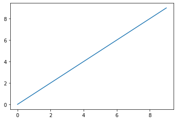

```python
plt.plot(data)
```

- Perceba que ele assume os valores da lista como sendo eixos x e y.
- Agora vamos plotar uma linha passando um lista para os valores do eixo x e outra lista para o eixo y.

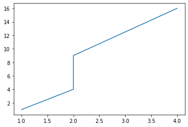

```python
xpoints = [1, 2, 2, 4]
ypoints = [1, 4, 9, 16]

plt.plot(xpoints, ypoints)
```

- Vamos adicionar rótulos nos eixos

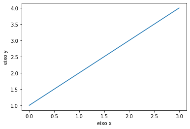

```python
plt.plot([1, 2, 3, 4])
plt.ylabel('eixo y')
plt.xlabel('eixo x')
plt.show()
```

### Formatando o estilo

- Para cada par de x e y, há um terceiro argumento opcional que é uma *string* que indica a cor e o estilo da linha no *plot*.
- O estilo padrão é 'b-', que siginifica *blue line*.
- No exemplo a seguir vamos apresentar os dados com marcadores em círculos vermelho.

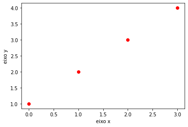

```python
plt.plot([1, 2, 3, 4], 'ro')
plt.ylabel('eixo y')
plt.xlabel('eixo x')
plt.show()
```

- Vejam outros exemplos de estilo

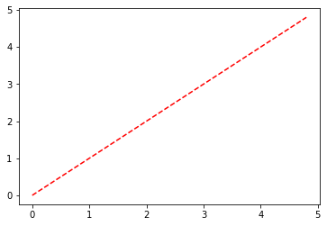

```python
t = np.arange(0., 5., 0.2)

plt.plot(t, t, 'r--')
plt.show()
```

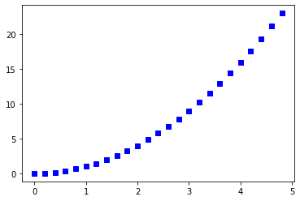

```python
t = np.arange(0., 5., 0.2)

plt.plot(t, t**2, 'bs')
plt.show()
```

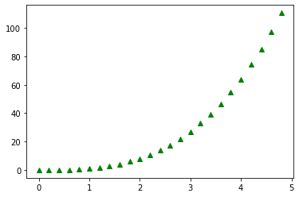

```python
t = np.arange(0., 5., 0.2)

plt.plot(t, t**3, 'g^')
plt.show()
```

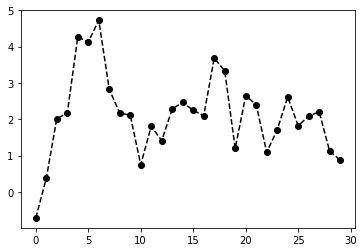

```python
plt.plot(np.random.randn(30).cumsum(), 'ko--')
```

- É possível também utilizar os parâmetros *linestyle* e *color*

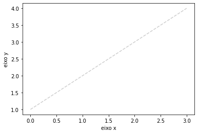

```python
plt.plot([1, 2, 3, 4], linestyle='--', color='#CECECE')
plt.ylabel('eixo y')
plt.xlabel('eixo x')
plt.show()
```

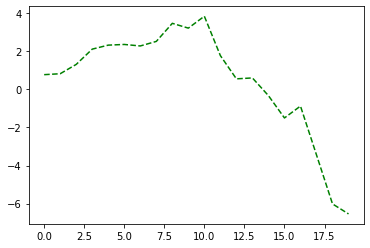

```python
plt.plot(np.random.randn(20).cumsum(), linestyle='dashed', color='g')
```

- Aumentando o tamanho do marcador

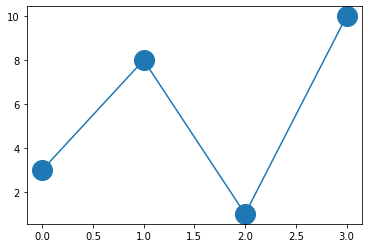

```python
ypoints = np.array([3, 8, 1, 10])

plt.plot(ypoints, marker = 'o', ms = 20)
plt.show()
```

- Alterando a cor do contorno do marcador

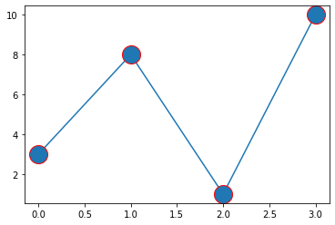

```python
ypoints = np.array([3, 8, 1, 10])

plt.plot(ypoints, marker = 'o', ms = 20, mec = 'r')
plt.show()
```

- Alterando a cor de preenchimento do marcador

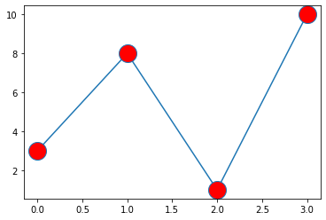

```python
ypoints = np.array([3, 8, 1, 10])

plt.plot(ypoints, marker = 'o', ms = 20, mfc = 'r')
plt.show()
```

- Alterando a espessura da linha

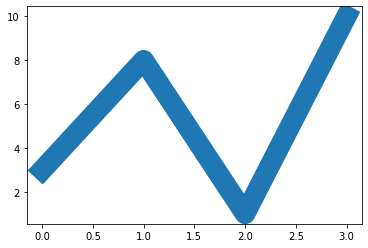

```python
ypoints = np.array([3, 8, 1, 10])

plt.plot(ypoints, linewidth = '20.5')
plt.show()
```

### Atividade

- Apresente um grafico de linha das vendas feitas semanalmente (*Weekly_Sales*) pela loja 40 do Walmart

```python
df = pd.read_csv('datasets/Walmart_Store_sales.csv')
df.head(3)
```

|  | Store | Date | Weekly_Sales | Holiday_Flag | Temperature | Fuel_Price | CPI | Unemployment |
| --- | --- | --- | --- | --- | --- | --- | --- | --- |
| 0 | 1 | 05-02-2010 | 1643690.90 | 0 | 42.31 | 2.572 | 211.096358 | 8.106 |
| 1 | 1 | 12-02-2010 | 1641957.44 | 1 | 38.51 | 2.548 | 211.242170 | 8.106 |
| 2 | 1 | 19-02-2010 | 1611968.17 | 0 | 39.93 | 2.514 | 211.289143 | 8.106 |

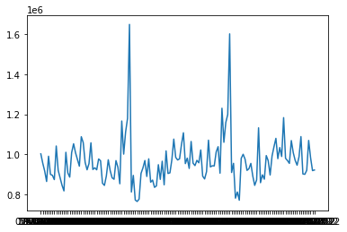

```python
df_p1 = df[df['Store']==40]
plt.plot(df_p1['Date'], df_p1['Weekly_Sales'])
```

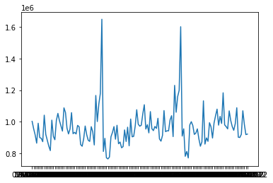

```python
df_p1 = df[df['Store']==40]
plt.plot(df_p1['Date'], df_p1['Weekly_Sales'])
```

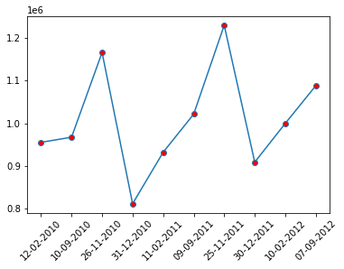

```python
df_p2 = df[df['Store']==40]
df_p2 = df_p2[df_p2['Holiday_Flag']==1]
plt.xticks(rotation=45)
plt.plot(df_p2['Date'], df_p2['Weekly_Sales'], marker = 'o', mfc = 'r')
```

- Apresente um grafico de linha tracejada na cor vermelha da temperatura semanal (*Temperature*) da loja 45 do Walmart, levando em consideração apenas as semanas com feriados (*Holiday_Flag*). Na imagem gerada, utilizem marcadores vermelhos de tamanho 15 para destacar os pontos x e y

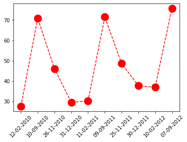

```python
df_p2 = df[df['Store']==45]
df_p2 = df_p2[df_p2['Holiday_Flag']==1]
plt.xticks(rotation=45)
plt.plot(df_p2['Date'], df_p2['Temperature'], marker = 'o', mfc = 'r', ms=15, linestyle='dashed', color='r')
```

### Figuras e subplotagens

- As plotagens na matplotlib ficam em um objeto **Figure**. Podemos criar uma nova figura com plt.figure:

```python
fig = plt.figure()
```

- Como vocês podem observar, nada foi exibido.
- No IPython, uma janela de plotagem vazia apareceria.
- Não é possível criar uma plotagem com uma figura em branco. Você deve criar uma ou mais subplots usando add_subplot.

```python
ax1 = fig.add_subplot(2,2,1)
```

- Essa instrução significa que a figura deve ser de 2x2 (portanto até quatro plotagens no total), e estamos selecionando a primeira das quatro subplotagens.
- Se criarmos mais duas subplotagens, acabaremos com uma visualização que tem o aspecto mostrado a seguir.

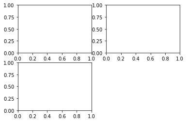

```python
fig = plt.figure()
ax1 = fig.add_subplot(2,2,1)
ax2 = fig.add_subplot(2,2,2)
ax3 = fig.add_subplot(2,2,3)
```

- Quando executamos um comando de plotagem como *plt.plot()*, a matplotlib desenhará na última figura e subplotagem usadas (criando uma, se for necessário), ocultando, assim, a criação da figura e da subplotagem.

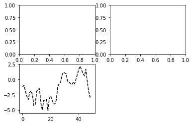

```python
fig = plt.figure()
ax1 = fig.add_subplot(2,2,1)
ax2 = fig.add_subplot(2,2,2)
ax3 = fig.add_subplot(2,2,3)
plt.plot(np.random.randn(50).cumsum(), 'k--')
```

- O 'k--' é uma opção de estilo para plotar linha tracejada preta.
- Podemos plotar diretamente nas outras subplotagens vazias chamando o método de instância de cada uma.

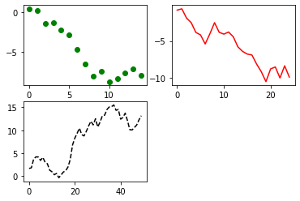

```python
fig = plt.figure()
ax1 = fig.add_subplot(2,2,1)
ax2 = fig.add_subplot(2,2,2)
ax3 = fig.add_subplot(2,2,3)
plt.plot(np.random.randn(50).cumsum(), 'k--')
_ = ax1.plot(np.random.randn(15).cumsum(), 'go')
ax2.plot(np.random.randn(25).cumsum(), 'r')
```

- Uma outra forma mais conveniente de criar subplotagens é utilizando o método **plt.subplots()**, que cria uma nova figura e devolve um array Numpy contendo os objetos de subplotagem criados

```
array([[<AxesSubplot:>, <AxesSubplot:>],
       [<AxesSubplot:>, <AxesSubplot:>]], dtype=object)
```

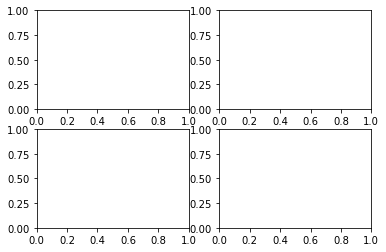

```python
fig, ax = plt.subplots(2,2)
ax
```

- Assim o *array* ax pode ser facilmente indexado como um *array* bidimensional.
- Vamos criar uma figura agora com mais de um dado compartilhando o mesmo quadro

```python
y1 = np.array([3, 8, 1, 10])
y2 = np.array([6, 2, 7, 11])

plt.plot(y1)
plt.plot(y2)

plt.show()
```

[output not shown]

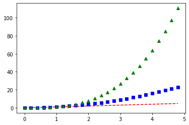

```python
t = np.arange(0., 5., 0.2)

plt.plot(t, t, 'r--', t, t**2, 'bs', t, t**3, 'g^')
plt.show()
```

### Ajustando o espaçamento em torno das subplotagens

- Por padrão a matplotlib deixa determinado espaço para preenchimento em torno das subplotagens, além de um espaçamento entre elas.
- Todas esse espaçamentos são especificados em relação à altura e à largura da plotagem, de modo que, se você redimensionar a plotagem, ela se justará dinamicamente.
- O espaçamento pode ser alterado usando o método **subplots_adjust()** dos objetos **Figure**.
- Os argumentos wspace e hspace controlam o percentual da largura e da altura da figura, respectivamente, a serem usados como espaçamento entre as subplotagens.

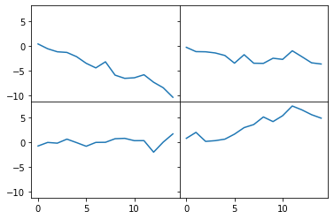

```python
fig, ax = plt.subplots(2, 2, sharex=True, sharey=True)
for i in range(2):
    for j in range(2):
        ax[i,j].plot(np.random.randn(15).cumsum())
plt.subplots_adjust(wspace=0, hspace=0)
```

- Percebam a utilização dos parâmetros **sharex** e **sharey**. Eles fazem com que todos os parâmetros compartilhem respectivamente os eixos x e y.

### Definindo o título e os tiques

- Adição de título e legenda

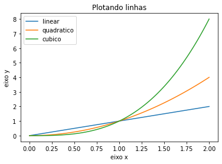

```python
x = np.linspace(0, 2, 100)

fig, ax = plt.subplots()  # Cria uma figura e os eixos
ax.plot(x, x, label='linear')  # Plotando dados
ax.plot(x, x**2, label='quadratico')  # Plotando mais dados
ax.plot(x, x**3, label='cubico')  # ... e mais.
ax.set_xlabel('eixo x')  # Adicionando rótulo no eixo x.
ax.set_ylabel('eixo y')  # Adicionando rótulo no eixo y.
ax.set_title("Plotando linhas")  # Adicionando um título.
ax.legend()  # Adicionando uma legenda.
```

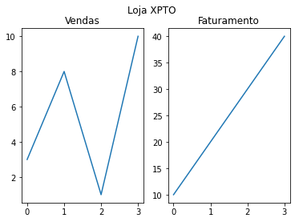

```python
#plot 1:
x = np.array([0, 1, 2, 3])
y = np.array([3, 8, 1, 10])

plt.subplot(1, 2, 1)
plt.plot(x,y)
plt.title("Vendas")

#plot 2:
x = np.array([0, 1, 2, 3])
y = np.array([10, 20, 30, 40])

plt.subplot(1, 2, 2)
plt.plot(x,y)
plt.title("Faturamento")

plt.suptitle("Loja XPTO")
plt.show()
```

- Alterando as propriedades da fonte

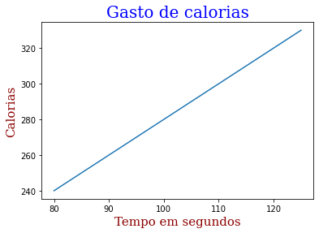

```python
x = np.array([80, 85, 90, 95, 100, 105, 110, 115, 120, 125])
y = np.array([240, 250, 260, 270, 280, 290, 300, 310, 320, 330])

font1 = {'family':'serif','color':'blue','size':20}
font2 = {'family':'serif','color':'darkred','size':15}

plt.title("Gasto de calorias", fontdict = font1)
plt.xlabel("Tempo em segundos", fontdict = font2)
plt.ylabel("Calorias", fontdict = font2)

plt.plot(x, y)
plt.show()
```

- Alterando o posicionamento do título

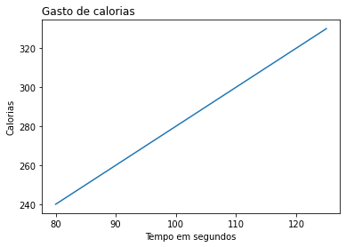

```python
x = np.array([80, 85, 90, 95, 100, 105, 110, 115, 120, 125])
y = np.array([240, 250, 260, 270, 280, 290, 300, 310, 320, 330])

plt.title("Gasto de calorias", loc = 'left')
plt.xlabel("Tempo em segundos")
plt.ylabel("Calorias")

plt.plot(x, y)
plt.show()
```

- Personalizando os eixos
- Para alterar os tiques do eixo x, a opção mais simples é usar set_xticks e set_xticklabels. A primeira instrui a matplotlib acerca do local para posicionar os tiques no intervalo de dados; por padrão, esses locais também serão os rótulos.

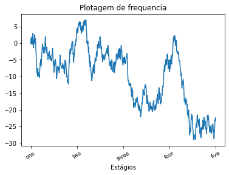

```python
fig = plt.figure()
ax = fig.add_subplot(1,1,1)
ax.plot(np.random.randn(1000).cumsum())

ax.set_xticks([0,250,500,750,1000])
ax.set_xticklabels(['one', 'two', 'three', 'four', 'five'], rotation=30, fontsize='small')
ax.set_title("Plotagem de frequencia")
ax.set_xlabel('Estágios')
```

- Percebam que podemos definir qualquer outro valor como rótulos usando set_xticklabels()
- A opção *rotation* define os rótulos dos tiques de x com uma rotação de 30º

### Atividade

- Apresente um subplots de gráficos de temperaturas semanais das lojas 40, 41, 42 e 43 do Walmart filtrando pelo ano de 2010

```python
from datetime import datetime
```

```python
df = pd.read_csv('datasets/Walmart_Store_sales.csv')
df['Date'] = pd.to_datetime(df['Date'], format="%d-%m-%Y")
df.head(3)
```

|  | Store | Date | Weekly_Sales | Holiday_Flag | Temperature | Fuel_Price | CPI | Unemployment |
| --- | --- | --- | --- | --- | --- | --- | --- | --- |
| 0 | 1 | 2010-02-05 | 1643690.90 | 0 | 42.31 | 2.572 | 211.096358 | 8.106 |
| 1 | 1 | 2010-02-12 | 1641957.44 | 1 | 38.51 | 2.548 | 211.242170 | 8.106 |
| 2 | 1 | 2010-02-19 | 1611968.17 | 0 | 39.93 | 2.514 | 211.289143 | 8.106 |

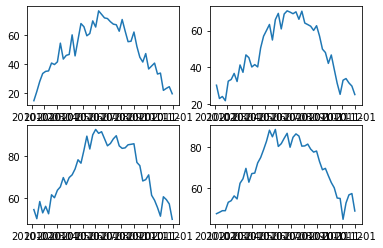

```python
fig = plt.figure()
ax1 = fig.add_subplot(2,2,1)
ax2 = fig.add_subplot(2,2,2)
ax3 = fig.add_subplot(2,2,3)
ax4 = fig.add_subplot(2,2,4)

df_p1 = df[df['Date'] < datetime(2011,1,1)]

df_ax1 = df_p1[df_p1['Store']==40]
df_ax2 = df_p1[df_p1['Store']==41]
df_ax3 = df_p1[df_p1['Store']==42]
df_ax4 = df_p1[df_p1['Store']==43]

ax1.plot(df_ax1['Date'], df_ax1['Temperature'])
ax2.plot(df_ax2['Date'], df_ax2['Temperature'])
ax3.plot(df_ax3['Date'], df_ax3['Temperature'])
ax4.plot(df_ax4['Date'], df_ax4['Temperature'])
```

- Apresente um subplots de gráficos de linhas das vendas feitas semanalmente (Weekly_Sales) pelas lojas 40, 41, 42 e 43 do Walmart filtrando pelo ano de 2010. Para facilitar a visualização, normalize os dados de vendas e ajuste o gráfico para que os subplots compartilhem os mesmos eixos (x e y)

```python
from sklearn.preprocessing import MinMaxScaler
```

```python
minmax_scale = MinMaxScaler().fit(df[['Weekly_Sales']])
df_minmax = minmax_scale.transform(df[['Weekly_Sales']])
df_minmax
```

```
array([[0.39729115],
       [0.39681079],
       [0.38850052],
       ...,
       [0.14533712],
       [0.1408095 ],
       [0.15249124]])
```

```python
df['Weekly_Sales_normalized'] = df_minmax
df.head(3)
```

|  | Store | Date | Weekly_Sales | Holiday_Flag | Temperature | Fuel_Price | CPI | Unemployment | Weekly_Sales_normalized |
| --- | --- | --- | --- | --- | --- | --- | --- | --- | --- |
| 0 | 1 | 2010-02-05 | 1643690.90 | 0 | 42.31 | 2.572 | 211.096358 | 8.106 | 0.397291 |
| 1 | 1 | 2010-02-12 | 1641957.44 | 1 | 38.51 | 2.548 | 211.242170 | 8.106 | 0.396811 |
| 2 | 1 | 2010-02-19 | 1611968.17 | 0 | 39.93 | 2.514 | 211.289143 | 8.106 | 0.388501 |

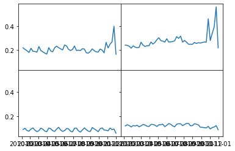

```python
fig, ax = plt.subplots(2, 2, sharex=True, sharey=True)

df_p1 = df[df['Date'] < datetime(2011,1,1)]

df_ax1 = df_p1[df_p1['Store']==40]
df_ax2 = df_p1[df_p1['Store']==41]
df_ax3 = df_p1[df_p1['Store']==42]
df_ax4 = df_p1[df_p1['Store']==43]

ax[0,0].plot(df_ax1['Date'], df_ax1['Weekly_Sales_normalized'])
ax[0,1].plot(df_ax2['Date'], df_ax2['Weekly_Sales_normalized'])
ax[1,0].plot(df_ax3['Date'], df_ax3['Weekly_Sales_normalized'])
ax[1,1].plot(df_ax4['Date'], df_ax4['Weekly_Sales_normalized'])

plt.subplots_adjust(wspace=0, hspace=0)
```

- Utilizando os mesmos dados de vendas normalizados da questão anterior, gere os gráficos de linhas das vendas normalizadas da loja 40 e 43 de modo que apareçam no mesmo mesmo quadro. Adicione título, rotulos do eixo x e y, e legenda para que seja possível identificar as linhas de cada loja.

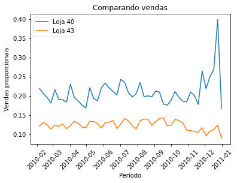

```python
fig, ax = plt.subplots()
plt.xticks(rotation=45)

ax.plot(df_ax1['Date'], df_ax1['Weekly_Sales_normalized'], label='Loja 40')
ax.plot(df_ax4['Date'], df_ax4['Weekly_Sales_normalized'], label='Loja 43')

ax.set_xlabel('Período')
ax.set_ylabel('Vendas proporcionais')
ax.set_title("Comparando vendas")
ax.legend()
```

### Adição de gride

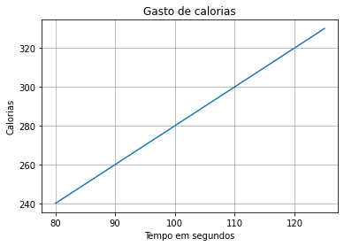

```python
x = np.array([80, 85, 90, 95, 100, 105, 110, 115, 120, 125])
y = np.array([240, 250, 260, 270, 280, 290, 300, 310, 320, 330])

plt.title("Gasto de calorias")
plt.xlabel("Tempo em segundos")
plt.ylabel("Calorias")

plt.plot(x, y)

plt.grid()

plt.show()
```

- Exibindo apenas gride no eixo x

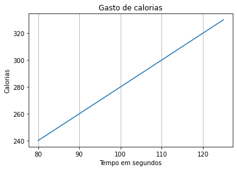

```python
x = np.array([80, 85, 90, 95, 100, 105, 110, 115, 120, 125])
y = np.array([240, 250, 260, 270, 280, 290, 300, 310, 320, 330])

plt.title("Gasto de calorias")
plt.xlabel("Tempo em segundos")
plt.ylabel("Calorias")

plt.plot(x, y)

plt.grid(axis = 'x')

plt.show()
```

- Exibindo apenas gride no eixo y

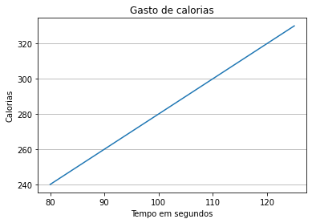

```python
x = np.array([80, 85, 90, 95, 100, 105, 110, 115, 120, 125])
y = np.array([240, 250, 260, 270, 280, 290, 300, 310, 320, 330])

plt.title("Gasto de calorias")
plt.xlabel("Tempo em segundos")
plt.ylabel("Calorias")

plt.plot(x, y)

plt.grid(axis = 'y')

plt.show()
```

- Alterando propriedades do gride

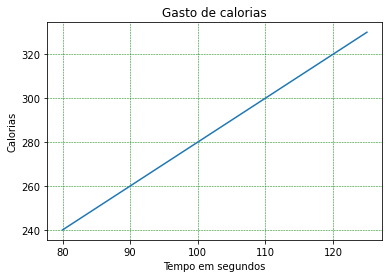

```python
x = np.array([80, 85, 90, 95, 100, 105, 110, 115, 120, 125])
y = np.array([240, 250, 260, 270, 280, 290, 300, 310, 320, 330])

plt.title("Gasto de calorias")
plt.xlabel("Tempo em segundos")
plt.ylabel("Calorias")

plt.plot(x, y)

plt.grid(color = 'green', linestyle = '--', linewidth = 0.5)

plt.show()
```

### Anotações básicas

- Um uso comum para texto é anotar alguma característica do *plot*.
- Em uma anotação há dois pontos a se considerar: a localização da forma (e.g., seta, círculo) e do texto sendo representados respectivamente pelos argumentos **xy** e **xytext**. Ambos esses argumentos são tuplas (x, y).

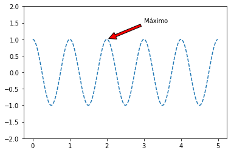

```python
t = np.arange(0.0, 5.0, 0.01)
s = np.cos(2*np.pi*t)

line = plt.plot(t, s, linestyle='dashed')

plt.annotate('Máximo', xy=(2, 1), xytext=(3, 1.5),
             arrowprops=dict(facecolor='red', shrink=0.05),
             )

plt.ylim(-2, 2)
plt.show()
```

- Vamos plotar mais uma anotação
- Vamos carregar o dataset com o preço das ações das *Big Techs* e selecionar aprenas as ações da IBM

```python
data = pd.read_csv('datasets/price_stocks.csv', index_col=0, parse_dates=True)
data.head(3)
```

| Date | AAPL | IBM | MSFT | GOOG |
| --- | --- | --- | --- | --- |
| 2010-01-04 | 6.57 | 91.51 | 23.99 | 312.20 |
| 2010-01-05 | 6.58 | 90.40 | 24.00 | 310.83 |
| 2010-01-06 | 6.48 | 89.81 | 23.86 | 302.99 |

- Vamos identificar as datas de quando a ação atingiu a sua máxima e a sua mínima

```python
data['IBM'].describe()
```

```
count    1510.000000
mean      125.820980
std        19.044084
min        84.560000
25%       115.117500
50%       130.600000
75%       140.950000
max       157.780000
Name: IBM, dtype: float64
```

```python
data[data['IBM']<85]
```

| Date | AAPL | IBM | MSFT | GOOG |
| --- | --- | --- | --- | --- |
| 2010-01-29 | 5.90 | 84.56 | 21.85 | 263.98 |
| 2010-02-04 | 5.90 | 84.98 | 21.58 | 262.41 |
| 2010-02-08 | 5.96 | 84.58 | 21.49 | 265.74 |

```python
data[data['IBM']>157]
```

| Date | AAPL | IBM | MSFT | GOOG |
| --- | --- | --- | --- | --- |
| 2013-03-14 | 13.48 | 157.78 | 23.70 | 409.24 |
| 2013-03-15 | 13.83 | 157.13 | 23.62 | 405.63 |
| 2013-03-20 | 14.09 | 157.23 | 23.85 | 405.83 |

- Agora vamos construir nosso *plot* anotando a máxima e a mínima

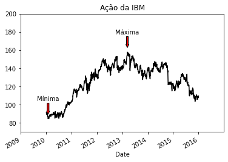

```python
fig = plt.figure()
ax = fig.add_subplot(1,1,1)

data = pd.read_csv('datasets/price_stocks.csv', index_col=0, parse_dates=True)
ibm = data['IBM']

ibm.plot(ax=ax, style='k-')

freq_data = [
    (datetime(2010, 1, 29), 'Mínima'),
    (datetime(2013, 3, 14), 'Máxima')
]

for date, label in freq_data:
    ax.annotate(label, xy=(date, ibm.asof(date) + 5),
                xytext=(date, ibm.asof(date)+25),
                arrowprops=dict(facecolor='red', headwidth=5, width=3, headlength=5),
                horizontalalignment='center', verticalalignment='top')

ax.set_xlim(['1/1/2009', '31/12/2016'])
ax.set_ylim([70, 200])

ax.set_title("Ação da IBM")
```

- Há alguns pontos importantes a serem enfatizados nessa plotagem:
  - o método *ax.annotate* é capaz de desenhar rótulos nas coordenadas x e y indicadas
  - os métodos *set_xlim* e *set_ylim* permitem definir manualmente as fronteiras de início e de fim da plotagem

### Salvando plotagens em arquivos

- Podemos salvar a figura ativa em um arquivo usando *plt.savefig*. O tipo de arquivo é inferido a partir de sua extensão.
- Há dois parâmetros importantes na exportação de gráficos:
  - **dpi**, que controla a resolução em pontos por polegada
  - **bbox_inches** que pode remover espaços em branco em torno da figura

```python
y1 = np.array([3, 8, 1, 10])
y2 = np.array([6, 2, 7, 11])

plt.plot(y1)
plt.plot(y2)

plt.savefig('example.png', dpi=400, bbox_inches='tight')
```

- Verifiquem se o *plot* foi salvo em arquivo na pasta desse notebook
- *savefig* não precisa escrever em disco, ele também pode escrever em qualquer objeto do tipo arquivo, como BytesIO

```python
from io import BytesIO
```

```python
y1 = np.array([3, 8, 1, 10])
y2 = np.array([6, 2, 7, 11])

plt.plot(y1)
plt.plot(y2)

buffer = BytesIO()

plt.savefig(buffer)
plot_data = buffer.getvalue()
```

### Criando gráfico de Barras

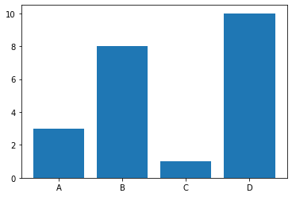

```python
x = np.array(["A", "B", "C", "D"])
y = np.array([3, 8, 1, 10])

plt.bar(x,y)
plt.show()
```

- Barras na horizonta

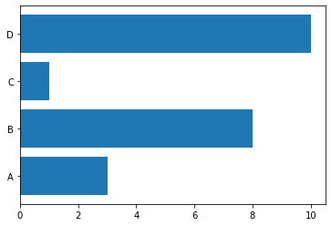

```python
x = np.array(["A", "B", "C", "D"])
y = np.array([3, 8, 1, 10])

plt.barh(x, y)
plt.show()
```

- Alterando as cores das barras

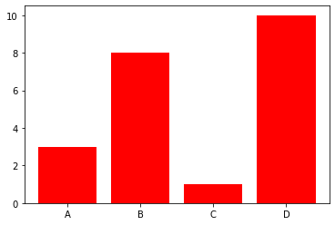

```python
x = np.array(["A", "B", "C", "D"])
y = np.array([3, 8, 1, 10])

plt.bar(x, y, color = "red")
plt.show()
```

- Alterando a largura das barras

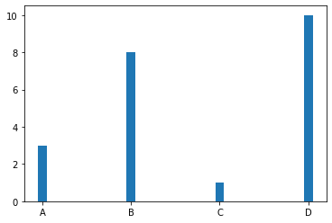

```python
x = np.array(["A", "B", "C", "D"])
y = np.array([3, 8, 1, 10])

plt.bar(x, y, width = 0.1)
plt.show()
```

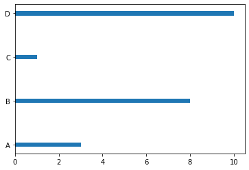

```python
x = np.array(["A", "B", "C", "D"])
y = np.array([3, 8, 1, 10])

plt.barh(x, y, height = 0.1)
plt.show()
```

### Criando Histograma

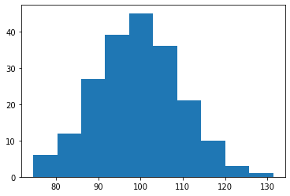

```python
x = np.random.normal(100, 10, 200)

plt.hist(x)
plt.show()
```

### Atividade

- Cria um gráfico de barras com a soma das vendas semanais por ano da loja 37 para identificar qual ano a loja vendeu mais.

```python
df = pd.read_csv('datasets/Walmart_Store_sales.csv')
df['Date'] = pd.to_datetime(df['Date'], format="%d-%m-%Y")
df.head(3)
```

|  | Store | Date | Weekly_Sales | Holiday_Flag | Temperature | Fuel_Price | CPI | Unemployment |
| --- | --- | --- | --- | --- | --- | --- | --- | --- |
| 0 | 1 | 2010-02-05 | 1643690.90 | 0 | 42.31 | 2.572 | 211.096358 | 8.106 |
| 1 | 1 | 2010-02-12 | 1641957.44 | 1 | 38.51 | 2.548 | 211.242170 | 8.106 |
| 2 | 1 | 2010-02-19 | 1611968.17 | 0 | 39.93 | 2.514 | 211.289143 | 8.106 |

```python
df_p1 = df[df['Store']==37] #Filtrando loja 37
df_p1 = df_p1[['Date','Weekly_Sales']] #Filtrando coluna Date e Weekly_Sales
df_p1['Year'] = df_p1['Date'].apply(lambda x: x.strftime('%Y')) #Pegando o ano da data
df_p1.set_index('Year', inplace=True)
del df_p1['Date']
df_p1
```

| Year | Weekly_Sales |
| --- | --- |
| 2010 | 536006.73 |
| 2010 | 529852.70 |
| 2010 | 510382.50 |
| 2010 | 513615.82 |
| 2010 | 519255.68 |
| ... | ... |
| 2012 | 527953.14 |
| 2012 | 546122.37 |
| 2012 | 521810.75 |
| 2012 | 551969.10 |
| 2012 | 534738.43 |

143 rows × 1 columns

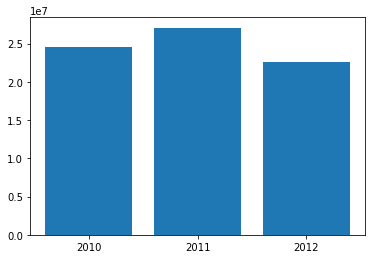

```python
years = df_p1.index.unique()
sums = [df_p1.loc[i].sum()[0] for i in df_p1.index.unique()]

plt.bar(years, sums)
plt.show()
```

- Apresente um gráfico de com as vendas semanais (*Weekly_Sales*) no feriado da loja 40 do Walmart. Adicione marcadores e uma anotação textual com a descrição dos feriados no gráfico. Não deixa que o texto da anotação ultrapasse os limites do quadro da figura.

```python
df_p1 = df[df['Store']==40].loc[(df['Date'] <= datetime(2010,12,31)) & (df['Holiday_Flag']==1)]
df_p1 = df_p1[['Date', 'Weekly_Sales']]
df_p1.set_index("Date",inplace=True)
df_p1
```

| Date | Weekly_Sales |
| --- | --- |
| 2010-02-12 | 955338.29 |
| 2010-09-10 | 967310.82 |
| 2010-11-26 | 1166142.85 |
| 2010-12-31 | 811318.30 |

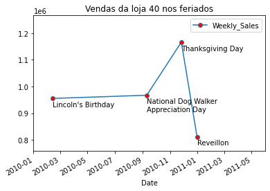

```python
fig = plt.figure()
ax = fig.add_subplot(1,1,1)

df_p1.plot(ax=ax, marker = 'o', mfc = 'r')

holidays = [
    (datetime(2010,2,12), 'Lincoln\'s Birthday'),
    (datetime(2010,9,10), 'National Dog Walker\nAppreciation Day'),
    (datetime(2010,11,26), 'Thanksgiving Day'),
    (datetime(2010,12,31), 'Reveillon'),
]

for date, label in holidays:
    ax.annotate(label, xy=(date, df_p1.asof(date)),
                xytext=(date, df_p1.asof(date)-10000),
                arrowprops=dict(facecolor='red', headwidth=0, width=0, headlength=0),
                horizontalalignment='left', verticalalignment='top')

ax.set_xlim(['2010/01/01', '2011/06/01'])
ax.set_ylim([758318.30, 1266142.85])

ax.set_title("Vendas da loja 40 nos feriados")
```

### Criando Scatter

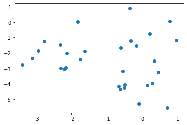

```python
x = np.random.randn(30).cumsum()
y = np.random.randn(30).cumsum()

plt.scatter(x, y)
plt.show()
```

- Desenhando dois plots na mesma figura

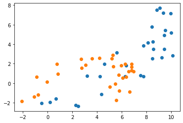

```python
x = np.random.randn(30).cumsum()
y = np.random.randn(30).cumsum()

plt.scatter(x, y)

x = np.random.randn(30).cumsum()
y = np.random.randn(30).cumsum()

plt.scatter(x, y)
plt.show()
```

- Definindo as cores dos marcadores

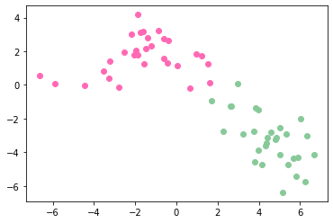

```python
x = np.random.randn(30).cumsum()
y = np.random.randn(30).cumsum()

plt.scatter(x, y, color = 'hotpink')

x = np.random.randn(30).cumsum()
y = np.random.randn(30).cumsum()

plt.scatter(x, y, color = '#88c999')
plt.show()
```

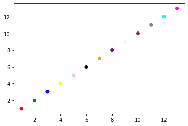

```python
x = [i for i in range(1,14)]
y = x
colors = np.array(["red","green","blue","yellow","pink","black","orange","purple","beige","brown","gray","cyan","magenta"])

plt.scatter(x, y, c=colors)

plt.show()
```

- Definindo um *array* de cores e especificando um mapa de cores

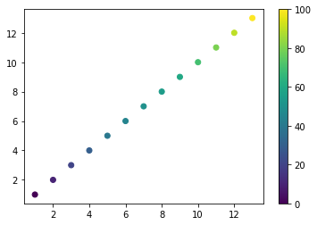

```python
x = [i for i in range(1,14)]
y = x
colors = np.array([0, 10, 20, 30, 40, 45, 50, 55, 60, 70, 80, 90, 100])

plt.scatter(x, y, c=colors, cmap='viridis')

plt.colorbar()

plt.show()
```

- Alterando o tamanho dos pontos

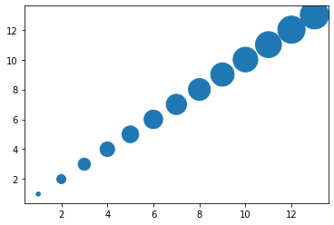

```python
x = [i for i in range(1,14)]
y = x
sizes = np.array([i for i in range(20,1000,80)])

plt.scatter(x, y, s=sizes)

plt.show()
```

- Ajustando a transparência dos pontos

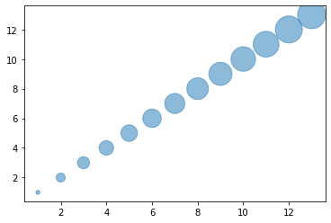

```python
x = [i for i in range(1,14)]
y = x
sizes = np.array([i for i in range(20,1000,80)])

plt.scatter(x, y, s=sizes, alpha=0.5)

plt.show()
```

### Criando Gráfico de Pizza

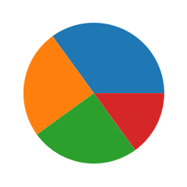

```python
y = np.array([35, 25, 25, 15])

plt.pie(y)
plt.show()
```

- Adicionando rótulos

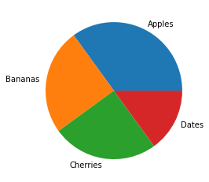

```python
y = np.array([35, 25, 25, 15])
labels = ["Apples", "Bananas", "Cherries", "Dates"]

plt.pie(y, labels = labels)
plt.show()
```

- Afastando as fatias do centro

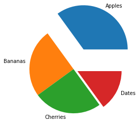

```python
y = np.array([35, 25, 25, 15])
labels = ["Apples", "Bananas", "Cherries", "Dates"]
explode = [0.5, 0, 0, 0.1]

plt.pie(y, labels = labels, explode = explode)
plt.show()
```

- Alterando as cores

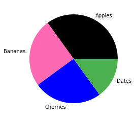

```python
y = np.array([35, 25, 25, 15])
labels = ["Apples", "Bananas", "Cherries", "Dates"]
colors = ["black", "hotpink", "b", "#4CAF50"]

plt.pie(y, labels = labels, colors = colors)
plt.show()
```

- Adicionando legenda

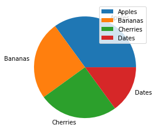

```python
y = np.array([35, 25, 25, 15])
labels = ["Apples", "Bananas", "Cherries", "Dates"]

plt.pie(y, labels = labels)
plt.legend()
plt.show()
```

### Visualizando Dados Geográficos

```python
housing = pd.read_csv('datasets/housing.csv')
```

```python
housing.head(3)
```

|  | longitude | latitude | housing_median_age | total_rooms | total_bedrooms | population | households | median_income | median_house_value | ocean_proximity |
| --- | --- | --- | --- | --- | --- | --- | --- | --- | --- | --- |
| 0 | -122.23 | 37.88 | 41.0 | 880.0 | 129.0 | 322.0 | 126.0 | 8.3252 | 452600.0 | NEAR BAY |
| 1 | -122.22 | 37.86 | 21.0 | 7099.0 | 1106.0 | 2401.0 | 1138.0 | 8.3014 | 358500.0 | NEAR BAY |
| 2 | -122.24 | 37.85 | 52.0 | 1467.0 | 190.0 | 496.0 | 177.0 | 7.2574 | 352100.0 | NEAR BAY |

- Vamos verificar a frequencia dos dados

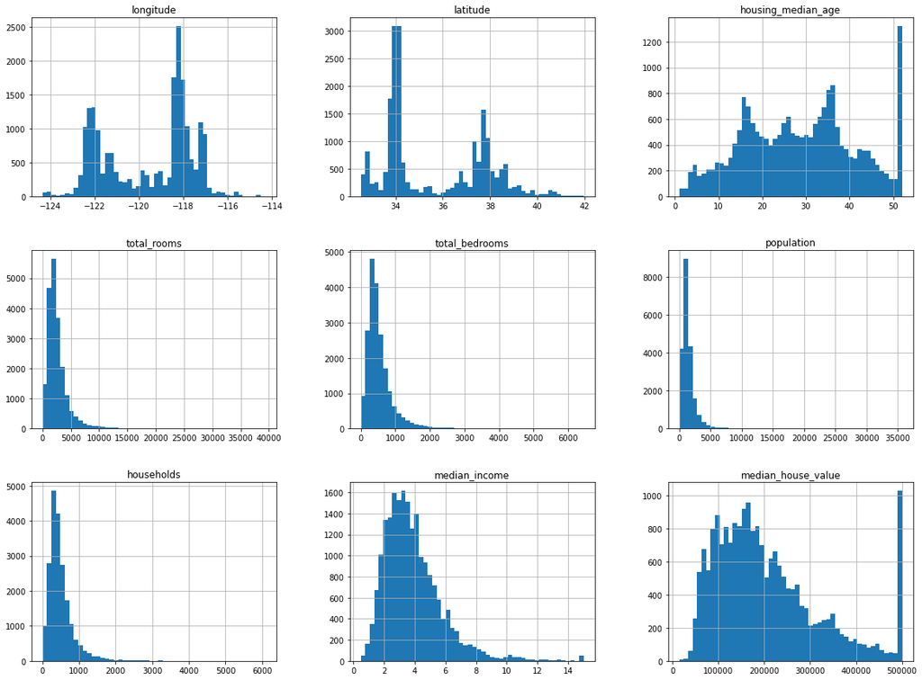

```python
housing.hist(bins=50, figsize=(20,15))
plt.show()
```

- Vamos plotar os dados de latitude e longitude

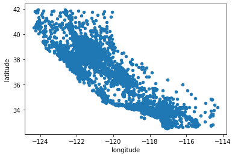

```python
housing.plot(kind="scatter", x="longitude", y="latitude")
```

- Vamos plotar novamente os dados de latitude e longitude de uma forma que seja possível visualizar os pontos mais frequentes.

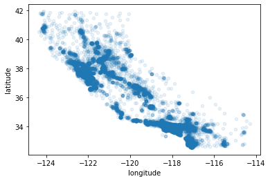

```python
housing.plot(kind="scatter", x="longitude", y="latitude", alpha=0.1)
```

- Agora vamos visualizar os locais onde possui maior concentração populacional e relacionar com a média de preço dos imóveis

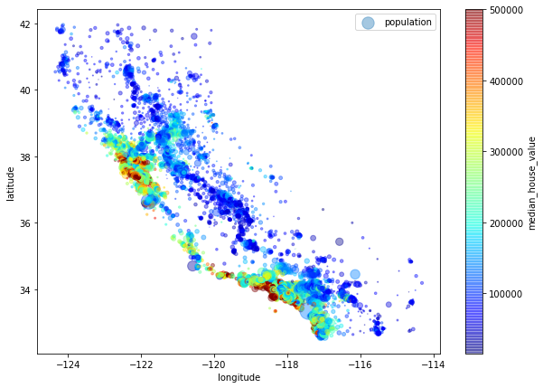

```python
housing.plot(kind="scatter", x="longitude", y="latitude", alpha=0.4,
             s=housing["population"]/100, label="population", figsize=(10,7),
             c="median_house_value", cmap=plt.get_cmap("jet"), colorbar=True,
             sharex=False)
plt.legend()
```

```python
import matplotlib.image as mpimg
```

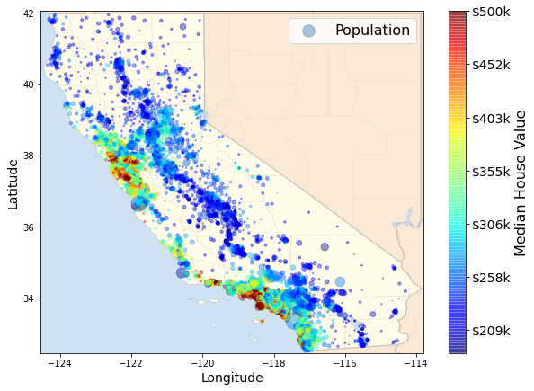

```python
california_img=mpimg.imread("figures/california.png")
ax = housing.plot(kind="scatter", x="longitude", y="latitude", figsize=(10,7),
                  s=housing['population']/100, label="Population",
                  c="median_house_value", cmap=plt.get_cmap("jet"),
                  colorbar=False, alpha=0.4)
plt.imshow(california_img, extent=[-124.55, -113.80, 32.45, 42.05], alpha=0.5,
           cmap=plt.get_cmap("jet"))
plt.ylabel("Latitude", fontsize=14)
plt.xlabel("Longitude", fontsize=14)

prices = housing["median_house_value"]
tick_values = np.linspace(prices.min(), prices.max(), 11)
cbar = plt.colorbar(ticks=tick_values/prices.max())
cbar.ax.set_yticklabels(["$%dk"%(round(v/1000)) for v in tick_values], fontsize=14)
cbar.set_label('Median House Value', fontsize=16)

plt.legend(fontsize=16)
plt.show()
```